# 4_DMW2021-Lab 4

```python
from IPython.display import HTML

HTML('''<script>
code_show=true;
function code_toggle() {
 if (code_show){
 $('div.input').hide();
 } else {
 $('div.input').show();
 }
 code_show = !code_show
}
$( document ).ready(code_toggle);
</script>
<form action="javascript:code_toggle()"><input type="submit"
value="Click here to toggle on/off the raw code."></form>''')
```

```python
from IPython.core.display import HTML
HTML("""
<style>
.output_png {
    display: table-cell;
    text-align: center;
    vertical-align: middle;
}
</style>
""")
```

```python
import re
import time
import os.path
import warnings
import datetime
import numpy as np
import pandas as pd
import seaborn as sns
import matplotlib.pyplot as plt
from scipy.cluster.hierarchy import fcluster
from scipy.cluster.hierarchy import linkage, dendrogram

from IPython.display import Image
from IPython.core.display import HTML

from sklearn.preprocessing import MinMaxScaler
from sklearn.preprocessing import StandardScaler
from sklearn.decomposition import PCA, TruncatedSVD

import warnings
warnings.simplefilter(action='ignore', category=FutureWarning)
warnings.filterwarnings("ignore", category=RuntimeWarning)
from warnings import simplefilter
from sklearn.exceptions import ConvergenceWarning
simplefilter("ignore", category=ConvergenceWarning)

from sqlalchemy import create_engine
from sqlalchemy.engine.reflection import Inspector
engine = create_engine('sqlite:///epl_df.db')
engine2 = create_engine('sqlite:///laliga_df.db')

plt.rcParams["figure.figsize"] = (6, 6)
```

```python
# PCA functions

def pca(X):
    """
    Perform Principal Component Analysis.

    """
    X_bar = np.mean(X, axis=0)
    X = X - X_bar

    cov = np.dot(X.T, X) # covariance
    eig_vals, eig_vecs = np.linalg.eig(cov)

    index = eig_vals.argsort()[::-1]
    eig_vals = eig_vals[index]
    eig_vecs = eig_vecs[:,index]

    X_new = np.matmul(X, eig_vecs)
    w = eig_vecs
    variance_explained = eig_vals / eig_vals.sum()

    return X_new, w, variance_explained

def plot_pca(X_new, features, w, pc_total):
    """
    Plot transformed data and features on to all vectors.

    """
    for i in range(pc_total-1):
        fig, ax = plt.subplots(1, 2, subplot_kw=dict(aspect='equal'),
                               gridspec_kw=dict(wspace=0.4), dpi=100)

        ax[0].scatter(X_new[:,i], X_new[:,i+1], marker='.', s=3,
                      c='rebeccapurple')
        ax[0].set_xlabel('PC' + str(i+1), fontsize=10)
        ax[0].set_ylabel('PC' + str(i+2), fontsize=10)
        ax[0].set_xlim(-1.5, 1.5)
        ax[0].set_ylim(-1.5, 1.5)

        for spine in ['top', 'right']:
            ax[0].spines[spine].set_visible(False)

        for feature, vec in zip(features, w):
            ax[1].arrow(0, 0, 2.5*vec[i], 2.5*vec[i+1], width=0.01,
                        ec='none', fc='forestgreen')
            ax[1].text(3*vec[i], 3*vec[i+1], feature, ha='center',
                       color='rebeccapurple', fontsize=5, weight='bold')

        #ax[1].set_xlim(-1, 1)
        #ax[1].set_ylim(-1, 1)
        ax[1].set_xlabel('PC' + str(i+1))
        ax[1].set_ylabel('PC' + str(i+2))
        ax[1].tick_params(axis='both',which='both',top=False, bottom=False,
                          labelbottom=False, labelleft=False, left=False)
        for spine in ['top', 'right', 'left', 'bottom']:
            ax[1].spines[spine].set_visible(False)

def plot_boxplot_eda(df_csv, col1, col2, col3, col4, n=4):
    """
    Plot boxplots for each feature, comparing clusters.

    """
    order = list(range(1, n+1))

    fig, (ax1, ax2, ax3, ax4) = plt.subplots(1, 4, figsize=(12, 2), dpi=70)

    sns.boxplot(data=df_csv, x='cluster', y=col1, palette='viridis',
                linewidth=1, ax=ax1, order=order)
    ax1.set(title=col1.title(), xlabel='Cluster', ylabel='')

    sns.boxplot(data=df_csv, x='cluster', y=col2, palette='viridis',
                linewidth=1, ax=ax2, order=order)
    ax2.set(title=col2.title(), xlabel='Cluster', ylabel='')

    sns.boxplot(data=df_csv, x='cluster', y=col3, palette='viridis',
                linewidth=1, ax=ax3, order=order)
    ax3.set(title=col3.title(), xlabel='Cluster', ylabel='')

    sns.boxplot(data=df_csv, x='cluster', y=col4, palette='viridis',
                linewidth=1, ax=ax4, order=order)
    ax4.set(title=col4.title(), xlabel='Cluster', ylabel='')
    plt.show()

def plot1(Z):
    """
    Plot the corresponding dendogram.

    """
    fig, ax = plt.subplots()
    dn = dendrogram(Z, truncate_mode='level', p=5, ax=ax)
    ax.set_ylabel(r'$\Delta$')
    return ax
```

[figure not shown]

```python
Image(filename="header.PNG")
```

# Scouting the EPL: Player Clusters in the English Premier League

## Executive Summary

With close to four billion fans around the world, football has become a worldwide phenomenon. Competition has been topnotch as leagues have been investing heavily in their players and their programs. The English Premier League is one of the top-tier leagues that boasts of having the best players in the world. Acquisitions and transfers are common in the world of football since all teams want to ramp up their chances of winning the coveted title. The quality and diversity of players have also improved in recent years, signalling better inclusion and a higher caliber of players. With the recent digital age, teams and leagues now have means to gather information on player statistics. Websites such as FBREF.com are good examples of legitimate sources of game data.

In this technical paper, our group analyzed various player and game statistics from FBREF.com. Data was extracted using manual webscraping, stored in a database, cleaned, and normalized. The data was divided into two dataframes; one for numerical statistics and the other for information like team, name, and positions. The first dataframe was used for dimensionality reduction and clustering while the latter was utilized for data exploration and analysis. Principal Component Analysis was performed to determine the correlation between features and to reduce the number of dimensions. Clustering was then executed via Ward's method of clustering. The team identified twelve new clusters; four unique clusters for each playing position. For Forwards, there are All-Around Forwards, Natural forwards, Aerial Forwards, and Defensive-Minded Forwards. For Midfielders, there are Utility Midfielders, Wide Midfielders, Holding Midfielders, and Attacking Midfielders. Finally, for Defenders, there are the Wing Backs, Full Backs, Ball-Playing Defenders, and Ball-Winning Defenders. The newly-formed clusters can be utilized by sports teams, coaches, managers, analysts, scouts, and fans for scouting, acquisitions, competition, and research.

This paper features data for players and statistics only in the 2020-2021 season of the English Premier League. We recommend future researchers to expand the scope of player statistics and go beyond the last football season. We suggest that they cover football leagues beyond the English Premier League such as the Italian Serie A, the Spanish La Liga, the FIFA World Cup, and even the Olympics. We also encourage future proponents to delve into more advanced data science techniques such as machine learning models so as to span more ground with their study and investigation. Finally, we recommend exploring other clustering methods and possibly looking into soft clusters for deeper analysis, relevant insights, and timely recommendations.

- Executive Summary
- Introduction
- Problem Statement and Motivation
- Data Description
- Methodology
  - Data Extraction and Storage
  - Data Cleaning and Merging
  - Exploratory Data Analysis
  - Dimensionality Reduction
  - Clustering
- Results
  - Exploratory Data Analysis
  - Per Position Analysis
    - Dimensionality Reduction
    - Clustering
- Conclusion and Recommendation
- References

## 1. Introduction

### Premier League

**The Premier League**, often referred to as the **English Premier League** or the **EPL** is the top level of the English football league system. It is contested by twenty football clubs and operates on a system of promotion and relegation with the English Football League (EFL). Seasons run from August to May with each team playing 38 matches (playing all 19 other teams both home and away). Most games are played on Saturday and Sunday afternoons. The competition was founded as the FA Premier League on February 20, 1992 following the decision of clubs in the Football League First Division to break away from the Football League and take advantage of a lucrative television rights sale. The Premier League is a corporation where chief executive Richard Masters is responsible for its management and the member clubs act as shareholders.

The Premier League is the most-watched sports league in the world, broadcasted in 212 territories to 643 million homes and a potential TV audience of 4.7 billion people. For the 2018–2019 season the average Premier League match attendance was at 38,181 while the aggregated attendance across all matches was the highest of any league at 14,508,981. Most stadium occupancies are always at near capacity. The English top-flight has produced the second-highest number of UEFA Champions League/European Cup titles, with five English clubs having won fourteen European trophies in total. Fifty clubs have competed since the inception of the Premier League in 1992, with Manchester United leading all club teams at 13 title wins.

### Football Positions

In football, each of the 11 players on a team is assigned to a particular position on the field of play. A team is made up of one goalkeeper and ten outfield players who fill various defensive, midfield, and attacking positions depending on the formation deployed. These positions describe both the player's main role and their area of operation on the pitch.

- **Forwards** (or strikers) are the players who are positioned nearest to the opposing team's goal. The primary responsibility of forwards is to score goals and to create scoring chances for other players. Forwards may also contribute defensively by harrying opposition defenders and goalkeepers while not in possession.
- **Midfielders** (originally called half-backs) are players whose position of play is midway between the attacking forwards and the defenders. Their main duties are to maintain possession of the ball, taking the ball from defenders and feeding it to the strikers, as well as dispossessing opposing players. Most managers field at least one central midfielder with a marked task of breaking up opposition's attacks while the rest are more adept to creating goals or have equal responsibilities between attack and defence. Midfielders can be expected to cover many areas of a pitch, as at times they can be called back into defence or required to attack with the forwards. They are more often the players that initiate attacking plays for a team.
- **Defenders** play behind the midfielders and their primary responsibility is to provide support to the team and to prevent the opposition from scoring a goal. They usually remain in the half of the field that contains the goal they are defending. Taller defenders will move forward to the opposing team's penalty box when their team takes corner kicks or free kicks, where scoring with one's head is a possibility.
- The **goalkeeper** has the most defensive position in football. The goalkeeper's main job is to stop the other team from scoring by catching, palming or punching the ball from shots, headers, and crosses. Unlike their teammates, goalkeepers typically remain in and around their own penalty area for most of the game. As a result, goalkeepers have a better view of the pitch and often give advice to their defence when the other team is on the attack.

### FBREF.COM

FBref.com is a website devoted to tracking statistics for football teams and players from around the world. FBref was created by Sports-Reference, the team behind popular statistics websites like **Baseball-Reference** and **Basketball-Reference**. They also feature American football, hockey, and college sports.

## 2. Problem Statement and Motivation

This technical report aims to unravel new and insightful player clusters based on athlete performance and on-field playing statistics in the English Premier League. Our findings will provide Football Clubs, team managers, player scouts, and game analyts with a descriptive and more in-depth analytical view of football playing positions and football players based on our discovered clusters. The insights gathered here can be utilized for player scouting, acquisition, and replacement. Scouts and managers are easily able to identify and profile players according to our clusters. Decision-makers from a particular Club or League are also able compare and analyze players from other top performing leagues for recruitment and competitive purposes. The proponents of this paper have only included players that played in the **2020-2021 season of the English Premier League**.

## 3. Data Description

All extracted data was saved in the **epl_df** database file. Nine tables were created for the data from the **fbref** website corresponding to specific categories of player statistics.

**Table 3.1 epl_df Database**

| Table Name | Description | Rows | Columns |
| --- | --- | --- | --- |
| main_stats | Contains cleaned and organized scraped data from FBRef's Standard Player Stats | 524 | 12 |
| keepers | Contains cleaned and organized scraped data from FBRef's Standard Goal Keeper Stats | 41 | 4 |
| shooting | Contains cleaned and organized scraped data from FBRef's Standard Shooting Stats | 524 | 5 |
| passing_type | Contains cleaned and organized scraped data from FBRef's Standard Passing Stats | 524 | 5 |
| gca | Contains cleaned and organized scraped data from FBRef's Standard Goal Creation Stats | 524 | 3 |
| defense | Contains cleaned and organized scraped data from FBRef's Standard Defensive Stats | 524 | 6 |
| possession | Contains cleaned and organized scraped data from FBRef's Standard Possession Stats | 524 | 5 |
| misc | Contains cleaned and organized scraped data from FBRef's Standard Miscellaneous Stats | 524 | 6 |
| complete | Contains merged scraped data from all FBRef's Stats Combined | 524 | 38 |

The **complete** table contains scraped data from the sites. It is the combination of the other 8 tables in terms of matching players. Below are the selected features found in the table:

**Table 3.2 Complete Table Feature Names, Types and Descriptions**

| Feature Name | Data Type | Feature | Description |
| --- | --- | --- | --- |
| player | str | Player Name | Name |
| nation | str | Nationality | Nationality |
| pos | str | Playing Position | Forward / Midfielder / Defender / Goalkeeper |
| squad | str | Team | Premier League Team |
| age | int64 | Age | Age |
| starts | int64 | Games Started | Games where the player is part of teh starting 11 |
| min | int | Minutes Played | Minutes played for the whole season |
| gls | int64 | Total Goals | Ball passing over the goal line, merits points |
| ast | int64 | Total Assists | Passes that led to a goal |
| crdr | int64 | Total Red Cards | Level 2 violations |
| crdy | int64 | Total Yellow Cards | Level 1 violations |
| ck | int64 | Total Corner Kicks | Free kicks from the field corner |
| cmp | int64 | Total Completed Passes | Moving the ball to another teammate |
| crs | int64 | Total Crosses | Passes from the wide to the middle area of the field |
| ti | int64 | Total Throw Ins Taken | Passes thrown into the field to restart game |
| gca | int64 | Total Goal Creating Actions | Action that led to goals scored |
| sca | int64 | Total Shot Creating Actions | Action that led to a shot opportunity |
| clr | int64 | Total Clearances | Sweeping the ball away from the opponents offensive end |
| int | int64 | Total Interceptions | Pass interceptions |
| tkl | int64 | Total Tackles | Hard challenges on your opponent |
| blocks | int64 | Total Blocks | Ball deflection |
| press | int64 | Total Defensive Presses | Close marking of opponent |
| fk | int64 | Total Free Kicks | Free kick awarded due to a foul |
| pk | int64 | Total Penalty Kicks | Free Kick given against solely the goalkeeper |
| sh | int64 | Total Shots | Attempted shots |
| sot | int64 | Total Shots on Target | Attempted shots directed at the goal |
| carries | int64 | Total Ball Carries | In possession of the ball moving forward |
| rec | int64 | Total Passes Received | Balls recieved from teammates |
| succ | int64 | Total Successful Dribbles | Carrying the ball past an opponent |
| touches | int64 | Total Ball Touches | Times the player touches the ball |
| fls | int64 | Total Fouls | Fouls commited |
| off | int64 | Total Offsides | Violations for wrong field position |
| og | int64 | Total Own Goals | Scoring a goal on your own net |
| recov | int64 | Total Recovered Loose Balls | Recovered loose balls |
| won | int64 | Total Aerials Duels Won | Fighting for loose balls in mid-air |

[figure not shown]

```python
Image(filename="method4.PNG")
```

## 4. Methodology

### 4.1 Data Extraction and Storage (Web Scraping)

Data was extracted from fbref.com through manual webscraping. Fbref.com was used to get player statistics data from the Premier League's 2020-2021 season (last season). The endpoint used was *https://fbref.com/en/comps/9/10728/table_name/2020-2021-Premier-League-Stats*. The website had several tables separated per players statistics category. The **table_name** in the endpoint pertains to the specific URL name of each table. Specific data was extracted from a total of nine tables **(Table 3.1)** and each was saved into a separate table in the main database **epl_df.db**. The player column which corresponds to the player’s name was used as the primary key of the table to uniquely identify every entry. The nine tables were eventually merged into a single FBRef table in the main database labeled as **complete**. The details on the code we used for scraping and merging can be found in the notebook named *Supplement* .

### 4.2 Data Cleaning, Filtering, and Normalization

The final tables were checked for any data that needed to be cleaned. The dual elements in the **pos** column were removed and the values for the **mins** column were converted to integer values. Goalkeeper data was not included in this report because their statistics are unique and are not applicable to other outfield players. We removed the following columns related to goalkeeper stats: **cs, pksv and saves**. Below is the sample table.

```python
# Call database
df_epl = pd.read_sql('select * from complete', engine)

# Delete goalkeeper stats
df_epl.drop(['cs', 'pksv', 'saves'], axis=1, inplace=True)

# Clean data
for i in range(df_epl.shape[0]):
    df_epl.loc[i, 'pos'] = df_epl['pos'].str.split(',')[i][0]

df_epl.replace(',', '', regex=True, inplace=True)
df_epl['min'] = df_epl['min'].astype(int)

# Filter players with less than 90 minutes of playing time
df_epl.drop(df_epl[df_epl['min'] < 90].index, inplace=True)
```

```python
# Display Sample Table

display(HTML('<center style="font-size:12px;font-style:default;">'
             '<b>Figure 4.1 Sample EPL Table</b>'
             '</center>'))

df_epl.head(10)
```

**Figure 4.1 Sample EPL Table**

|  | player | nation | pos | squad | age | starts | min | gls | ast | crdr | ... | sot | carries | rec | succ | touches | fls | off | og | recov | won |
| --- | --- | --- | --- | --- | --- | --- | --- | --- | --- | --- | --- | --- | --- | --- | --- | --- | --- | --- | --- | --- | --- |
| 0 | Patrick van Aanholt | NED | DF | Crystal Palace | 29 | 20 | 1777 | 0 | 1 | 0 | ... | 6 | 733 | 775 | 9 | 1323 | 11 | 3 | 0 | 179 | 10 |
| 1 | Tammy Abraham | ENG | FW | Chelsea | 22 | 12 | 1040 | 6 | 1 | 0 | ... | 13 | 177 | 251 | 6 | 356 | 22 | 5 | 0 | 47 | 39 |
| 2 | Che Adams | SCO | FW | Southampton | 24 | 30 | 2667 | 9 | 5 | 0 | ... | 31 | 630 | 734 | 25 | 976 | 29 | 19 | 0 | 119 | 47 |
| 3 | Tosin Adarabioyo | ENG | DF | Fulham | 22 | 33 | 2953 | 0 | 0 | 0 | ... | 5 | 1324 | 1491 | 8 | 2221 | 16 | 2 | 1 | 278 | 100 |
| 4 | Adrián | ESP | GK | Liverpool | 33 | 3 | 270 | 0 | 0 | 0 | ... | 0 | 50 | 46 | 0 | 113 | 0 | 0 | 0 | 20 | 0 |
| 5 | Sergio Agüero | ARG | FW | Manchester City | 32 | 7 | 559 | 4 | 1 | 0 | ... | 10 | 167 | 193 | 9 | 246 | 2 | 1 | 0 | 18 | 2 |
| 6 | Ola Aina | NGA | DF | Fulham | 23 | 31 | 2664 | 2 | 1 | 0 | ... | 4 | 1159 | 1230 | 21 | 2031 | 31 | 2 | 0 | 251 | 33 |
| 7 | Rayan Aït Nouri | FRA | DF | Wolves | 19 | 16 | 1404 | 1 | 1 | 0 | ... | 6 | 651 | 613 | 37 | 986 | 16 | 1 | 0 | 118 | 14 |
| 8 | Semi Ajayi | NGA | DF | West Brom | 26 | 31 | 2780 | 2 | 0 | 1 | ... | 4 | 611 | 627 | 12 | 1280 | 28 | 1 | 0 | 264 | 85 |
| 9 | Nathan Aké | NED | DF | Manchester City | 25 | 9 | 797 | 1 | 0 | 0 | ... | 1 | 607 | 656 | 0 | 821 | 8 | 0 | 0 | 80 | 30 |

10 rows × 35 columns

```python
# Create info and stats database
df_stats = df_epl.drop(['player', 'nation', 'pos', 'squad', 'age', 'starts',
                        'min'], axis=1)
df_info = df_epl[['player', 'nation', 'pos', 'squad', 'age', 'starts']]

# Filter players with less than 90 minutes of playing time
df_epl.drop(df_epl[df_epl['min'] < 90].index, inplace=True)

# Normalize
df_norm = df_stats.divide(df_epl['min'], axis=0)
df_norm = df_norm*90

# Split data into positions
df_fw = df_norm[df_info['pos'] == "FW"]
df_mf = df_norm[df_info['pos'] == "MF"]
df_df = df_norm[df_info['pos'] == "DF"]
```

### 4.3 Exploratory Data Analysis

- **Top Players by Stats**. The **complete table** in the main database **(epl_df)** was used to create dataframes containing the top players for both offensive and defensive individual game statistics . Columns filtered for offensive statistics include *player, gls, ast, sot, cmp* and are equivalent to Players, Goals, Assists, Shots on Target, and Passes respectively. On the other hand, defensive statistics that include *clr, int, tkl, and blocks* correspond to Clearances, Interceptions, Tackles, and Blocks. These values were sorted by player and the specific game statistic in descending order. These were then plotted through individual bar graphs.
- **Statistics by Goals**. For statistics on Goal points, the same data was used from the **complete table**. Values were grouped by Position(pos) and Age(age), the latter of which was divided into three buckets from 20-35 years of age. Both statistics were plotted against total goal points earned (gls).
- **Club Statistics**. For club statistics, players were grouped into their respective squads. The same offensive and defensive statistics in the previous per player analysis were used to identify trends and to highlight which teams performed exceptionally well.
- **Positions**. The Position (pos) column from the complete table was filtered to determine the distribution of playing positions among the Premier League players in the database. A bar graph was then plotted for proper visualization.
- **Nationality**. The Nations (nation) column from the complete table was used to determine the various nationalities of the English Premier League football players in our database. Similarly, a bar graph was utlilized for appropriate depiction.

### 4.5 Clustering

### Ward's Method

Ward's Linkage was used as the clustering method of choice. It is a type of hierarchical clustering where the cluster distance is measured by an increase in the sum-of-squared errors when merged. An advantage of this type of clustering is that one can easily navigate through subclusters as it is readily seen through a dendogram. In this report we tried to find the right balance between separation, composition, compactness, and the number of clusters.

## 5. Results

This portion of the report will contain the results of our Data Exploration, Dimensionality Reduction, and Clustering. We will include our insights and analysis on the main subtopics: Top Player Offensive and Defensive Statistics, Club Statistics, Nationalities, Positions, and Goal Points. We will then derive takeaways from our usage of Principal Component Analysis in determing the relevant components. Finally, we will discuss our newly formed clusters per playing position.

## 5.1 Exploratory Data Analysis

```python
# Create separate dataframes for EDA
df_eda = df_epl.copy()
```

### 5.1.1. Top Players by Stats

**Figure 5.1 Top 10 Players by Offensive Statistics for the English Premier League**

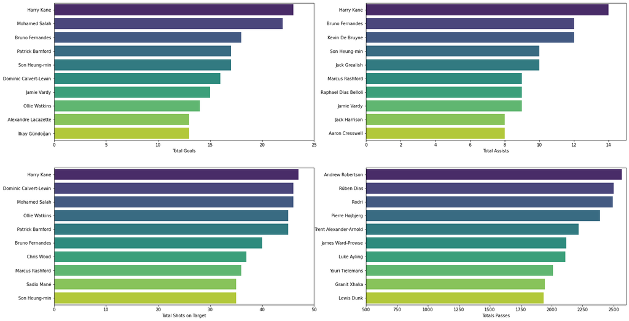

```python
# Goals
fig, ax = plt.subplots(2,2, sharey=False, figsize=(24,13))

# Create dataframe to filter goals and players
df_goals_epl = df_eda.sort_values\
(by='gls', ascending=False)[['player','gls']].head(10)

# Display Caption
display(HTML('<center style="font-size:12px;font-style:default;">'
             '<b>Figure 5.1 Top 10 Players by Offensive Statistics for the '+
             'English Premier League</b></center>'))

# Show Top 10 players by goals plot
sns.barplot(x=df_goals_epl["gls"],
            y=df_goals_epl["player"],
            palette='viridis',
            ci='None',
            capsize=1,
            ax=ax[0][0])

# Assists
# Create dataframe to filter assists and players
df_assists_epl = df_eda.sort_values\
(by='ast', ascending=False)[['player','ast']].head(10)

# Show Top 10 players by assists plot and players
sns.barplot(x=df_assists_epl["ast"],
            y=df_assists_epl["player"],
            palette='viridis',
            ci='None',
            capsize=1,
            ax=ax[0][1])

# Shots on Target
# Create dataframe to filter shots on target and players
df_sot_epl = df_eda.sort_values\
(by='sot', ascending=False)[['player','sot']].head(10)

# Show Top 10 Players by Shots on Target
sns.barplot(x=df_sot_epl["sot"],
            y=df_sot_epl["player"],
            palette='viridis',
            ci='None',
            capsize=1,
            ax=ax[1][0])

# Completed Passes
# Create dataframe to filter passes and players
df_cmp_epl = df_eda.sort_values\
(by='cmp', ascending=False)[['player','cmp']].head(10)

# Show Top 10 players by clean sheet
sns.barplot(x=df_cmp_epl["cmp"],
            y=df_cmp_epl["player"],
            palette='viridis',
            ci='None',
            capsize=1,
            ax=ax[1][1])

ax[0][0].set(xlabel='Total Goals', ylabel='')
ax[0][0].set_xlim(0,25)
ax[0][1].set(xlabel='Total Assists', ylabel='')
ax[0][1].set_xlim(0,15)
ax[1][0].set(xlabel='Total Shots on Target', ylabel='')
ax[1][0].set_xlim(0,50)
ax[1][1].set(xlabel='Totals Passes', ylabel='')
ax[1][1].set_xlim(500,2600)

plt.show()
```

The most important offensive individual player statistics that we want to highlight are **Goals, Assists, Shots on Target, and Passes.**

**Figure 5.2 Top 10 Players by Defensive Statistics for the English Premier League**

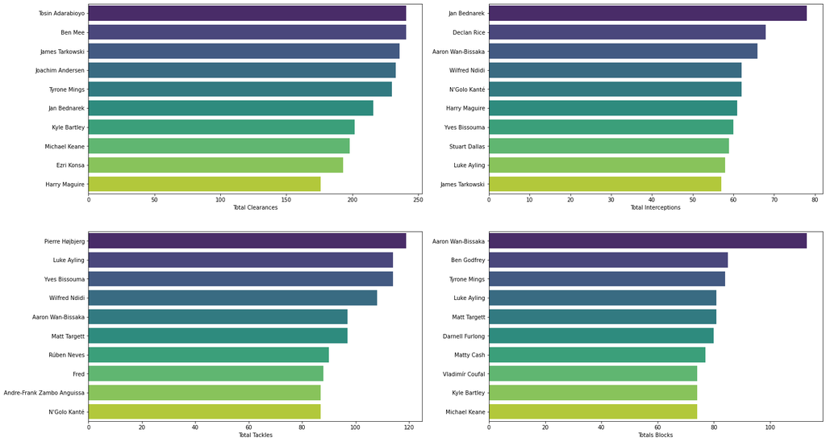

```python
# Clearances
fig, ax = plt.subplots(2,2, sharey=False, figsize=(24,14))

# Create dataframe to filter clearances and players
df_clear_epl = df_eda.sort_values\
(by='clr', ascending=False)[['player','clr']].head(10)

# Display Caption
display(HTML('<center style="font-size:12px;font-style:default;">'
             '<b>Figure 5.2 Top 10 Players by Defensive Statistics for the '+
             'English Premier League</b></center>'))

# Show Top 10 players by clearanes plot
sns.barplot(x=df_clear_epl["clr"],
            y=df_clear_epl["player"],
            palette='viridis',
            ci='None',
            capsize=1,
            ax=ax[0][0])

# Interceptions
# Create dataframe to filter interceptions and players
df_int_epl = df_eda.sort_values\
(by='int', ascending=False)[['player','int']].head(10)

# Show Top 10 players by interceptions plot
sns.barplot(x=df_int_epl["int"],
            y=df_int_epl["player"],
            palette='viridis',
            ci='None',
            capsize=1,
            ax=ax[0][1])

# Tackles
# Create dataframe to filter tackles and players
df_tkl_epl = df_eda.sort_values\
(by='tkl', ascending=False)[['player','tkl']].head(10)

#Show Top 10 players by tackles plot
sns.barplot(x=df_tkl_epl["tkl"],
            y=df_tkl_epl["player"],
            palette='viridis',
            ci='None',
            capsize=1,
            ax=ax[1][0])

# Blocks
# Create dataframe to filter blocks and players
df_blk_epl = df_eda.sort_values\
(by='blocks', ascending=False)[['player','blocks']].head(10)

# Show Top 10 Players by Crosses

sns.barplot(x=df_blk_epl["blocks"],
            y=df_blk_epl["player"],
            palette='viridis',
            ci='None',
            capsize=1,
            ax=ax[1][1])

ax[0][0].set(xlabel='Total Clearances', ylabel='')
ax[0][1].set(xlabel='Total Interceptions', ylabel='')
ax[1][0].set(xlabel='Total Tackles', ylabel='')
ax[1][1].set(xlabel='Totals Blocks', ylabel='')
plt.show()
```

### 5.1.2 Statistics by Goals

**Figure 5.3 Statistics by Goals for the English Premiere League**

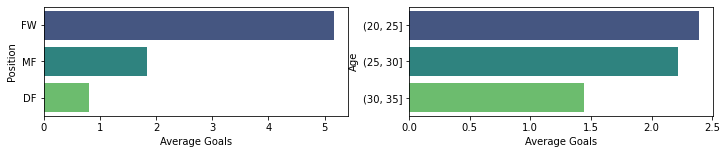

```python
# Graphs
fig, ax = plt.subplots(1,2, sharey=False, figsize=(12, 2))

# Average Goals per Position
pos_points_epl = df_eda.groupby('pos', as_index=False)['gls'].mean()
pos_points_epl.sort_values('gls', ascending=False, inplace=True)
pos_points_epl = pos_points_epl[pos_points_epl.pos != 'GK']

# Plot Average Goals per Position
sns.barplot(y='pos',
            x='gls',
            data=pos_points_epl,
            palette='viridis',
            ax=ax[0])

# Average Goals per age group
age_points_epl = df_eda.copy()
minage_epl = age_points_epl['age'].min()
maxage_epl = age_points_epl['age'].max()
age_range_epl = np.arange(20, 40, 5)
age_points_epl = (age_points_epl.groupby(pd.cut(age_points_epl["age"],
                                age_range_epl))['gls'].mean())
age_points_epl = age_points_epl.reset_index()
age_points_epl = age_points_epl.astype({'age': 'str'})
age_points_epl.sort_values('gls', ascending=False, inplace=True)

# Display Caption
display(HTML('<center style="font-size:12px;font-style:default;">'
             '<b> Figure 5.3 Statistics by Goals for the English Premiere'+
             ' League''</b></center>'))

# Plot Average Goals per Position
sns.barplot(x='gls',
            y='age',
            data=age_points_epl,
            palette="viridis",
            ax=ax[1])

ax[0].set(xlabel='Average Goals', ylabel='Position')
ax[1].set(xlabel='Average Goals', ylabel='Age')
plt.show()
```

We look into Goal Points by correlating it to Player Positions and Age.

- **Position**. As seen in the chart displaying Goal Points versus football player positions on the left section above, forwards have the highest goal points, with an average of 5. Forwards are those who play nearest to the opposing team's goal, and are therefore most responsible for scoring goals. Their advanced position and limited defensive responsibilities mean forwards normally score more goals on behalf of their team than other players. Midfielders are more defensive-minded but are occasionally called to move further into the field to assist and score. Midfielders in the 2020-2021 season of the English Premier League average almost 2 goals. In last place are defenders that focus more on defensives skills such as blocks and interceptions. Defenders averaged almost a point each for the whole season.
- **Age.** It is common in football and sports in general to assume that as athletes age, their performance slows down, affecting their individual playing statistics. There is also the concept of reaching one's peak performance at a certain age. Several studies provide some proof on the relationship between age and performance in football. The data from the 2020-2021 season of the English Premier League shows that football player ages range from as young as 20 years old to 35 years of age. The age range that scored the highest average goal points at 2.4 each is the 20-25 bracket. This is followed close by the 25-30 age bracket for football players that average around 2.2 goals. Coming in last is the 30-35 age range, averaging 1.4 goals.

### 5.1.3 Club Statistics

**Figure 5.4 English Premier League Club Statistics(Offense)**

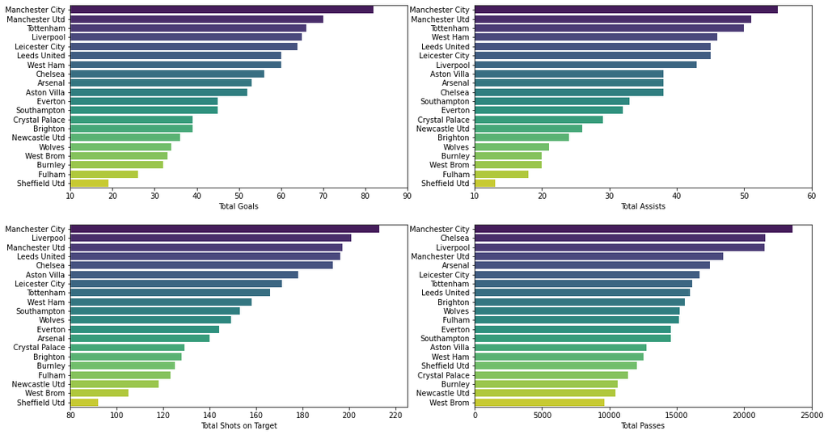

```python
# Display Caption
display(HTML('<center style="font-size:12px;font-style:default;">'
             '<b> Figure 5.4 English Premier League Club Statistics(Offense)'
             '</b></center>'))

# Team offense stats
fig, ax = plt.subplots(2, 2, sharey=False, figsize=(18,10))

# Team goals
goals_epl = df_eda.groupby('squad', as_index=False)['gls'].sum()
goals_epl.sort_values('gls', ascending=False, inplace=True)

sns.barplot(y='squad', x='gls', data=goals_epl, palette='viridis',
           ax=ax[0][0])

# Team assists
assists_epl = df_eda.groupby('squad', as_index=False)['ast'].sum()
assists_epl.sort_values('ast', ascending=False, inplace=True)

sns.barplot(y='squad', x='ast', data=assists_epl, palette='viridis',
           ax=ax[0][1])

# Team fantasy points
passes_epl = df_eda.groupby('squad', as_index=False)['cmp'].sum()
passes_epl.sort_values('cmp', ascending=False, inplace=True)

sns.barplot(y='squad', x='cmp', data=passes_epl,
            palette='viridis', ax=ax[1][1])

# Team shots on target
sot_epl = df_eda.groupby('squad', as_index=False)['sot'].sum()
sot_epl.sort_values('sot', ascending=False, inplace=True)

sns.barplot(y='squad', x='sot', data=sot_epl, palette='viridis',
           ax=ax[1][0])

ax[0][0].set(xlabel='Total Goals', ylabel='')
ax[0][0].set_xlim(10,90)
ax[0][1].set(xlabel='Total Assists', ylabel='')
ax[0][1].set_xlim(10,60)
ax[1][1].set(xlabel='Total Passes', ylabel='')
ax[1][1].set_xlim(0,25000)
ax[1][0].set(xlabel='Total Shots on Target', ylabel='')
ax[1][0].set_xlim(80,225)
plt.show()
```

Data of participating football teams was also analyzed and the prominent offensive and defensive stats per Premier League team were highlighted. The first set of graphs are for offense-related statistics. Manchester City led all teams in total goals, assists, passes and shots attempted last season. It is no wonder that Manchester City won the league that year.

**Figure 5.5 Club Statistics(Defense)**

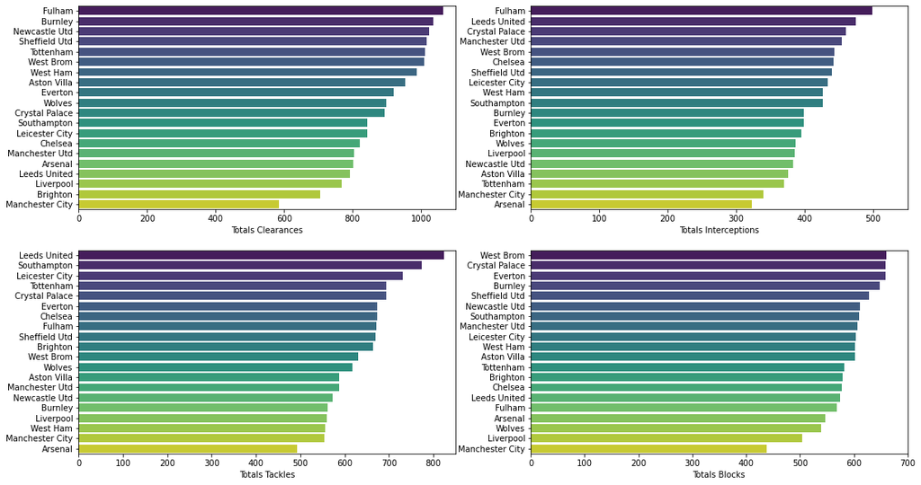

```python
# Defense stat plots
fig, ax = plt.subplots(2, 2, sharey=False, figsize=(18,10))

# Display Caption
display(HTML('<center style="font-size:12px;font-style:default;">'
             '<b> Figure 5.5 Club Statistics(Defense)'
             '</b></center>'))

# Team clearance
clearance_epl = df_eda.groupby('squad', as_index=False)['clr'].sum()
clearance_epl.sort_values('clr', ascending=False, inplace=True)

sns.barplot(y='squad', x='clr', data=clearance_epl, palette='viridis',
           ax=ax[0][0])

# Team interceptions
inter_epl = df_eda.groupby('squad', as_index=False)['int'].sum()
inter_epl.sort_values('int', ascending=False, inplace=True)

sns.barplot(y='squad', x='int', data=inter_epl, palette='viridis',
           ax=ax[0][1])

# Team tackles
tackles_epl = df_eda.groupby('squad', as_index=False)['tkl'].sum()
tackles_epl.sort_values('tkl', ascending=False, inplace=True)

sns.barplot(y='squad', x='tkl', data=tackles_epl, palette='viridis',
           ax=ax[1][0])

# Team blocks
blocks_epl = df_eda.groupby('squad', as_index=False)['blocks'].sum()
blocks_epl.sort_values('blocks', ascending=False, inplace=True)

sns.barplot(y='squad', x='blocks', data=blocks_epl, palette='viridis',
           ax=ax[1][1])

ax[0][0].set(xlabel='Totals Clearances', ylabel='')
ax[0][0].set_xlim(0, 1100)
ax[0][1].set(xlabel='Totals Interceptions', ylabel='')
ax[0][1].set_xlim(0,550)
ax[1][0].set(xlabel='Totals Tackles', ylabel='')
ax[1][0].set_xlim(0,850)
ax[1][1].set(xlabel='Totals Blocks', ylabel='')
ax[1][1].set_xlim(0,700)
plt.show()
```

### 5.1.4 Positions

**Figure 5.6 Player Distribution per Position**

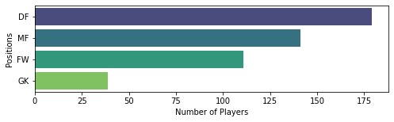

```python
# Plot Positions Bar Chart
pos_epl = df_eda.groupby('pos', as_index=False)['player'].count()
pos_epl.sort_values('player', ascending=False, inplace=True)

# Display Caption
display(HTML('<center style="font-size:12px;font-style:default;">'
             '<b> Figure 5.6 Player Distribution per Position '
             '</b></center>'))

fig, ax = plt.subplots(figsize=(8, 2))
sns.barplot(y='pos', x='player', data=pos_epl, palette='viridis', ax=ax);
ax.set_xlabel('Number of Players')
ax.set_ylabel('Positions');
```

Our data from the 2020-2021 EPL season shows that 179 Defenders, 141 Midfielders, 111 forwards, and 39 goalkeepers participated in the games.

### 5.1.5 Nationality

**Figure 5.7 Player Distribution by Nationality**

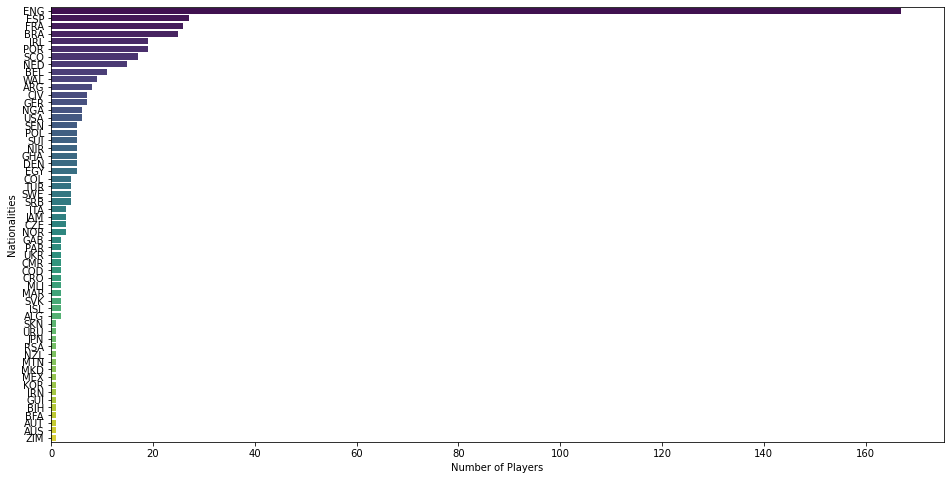

```python
# Plot Nationality Bar Chart
nation_epl = df_eda.groupby('nation', as_index=False)['player'].count()
nation_epl.sort_values('player', ascending=False, inplace=True)

# Display Caption
display(HTML('<center style="font-size:12px;font-style:default;">'
             '<b> Figure 5.7 Player Distribution by Nationality'
             '</b></center>'))

fig, ax = plt.subplots(figsize=(16, 8))
sns.barplot(y='nation', x='player', data=nation_epl,
            palette='viridis', ax=ax);
ax.set_xlabel('Number of Players')
ax.set_ylabel('Nationalities');
```

As expected, the English Premier League is dominated by British players. Some sources consider the league today as much more intercontinental than it was when it was launched in 1992. Although dominated by players from the UK, there are now more players from other parts in Europe, North and South America, Asia, Africa and Australia whereas in 1992 it was mainly Europe and North America. It is also known that nations such as France, Spain, Brazil and Portugal have become big sources of talent for the Premier League in recent years. This is backed up by data through the distribution of nationalities as seen above.

## 5.2 Dimensionality Reduction and Clustering

### 5.2.1 Forwards

### 5.2.1.1 Principal Component Analysis

To represent **90%** of the explained variance, we will need **14 principal components**. We will take the top features of only the top 3 PCs in our visualization.

**Figure 5.8 Scree Plot for Explained Variance - Forwards**

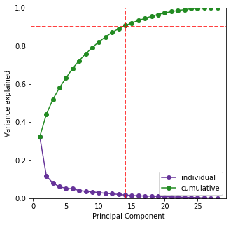

```python
# Prepare dataset for PCA
df_pca = df_fw.copy()

# Display Caption
display(HTML('<center style="font-size:12px;font-style:default;">'
             '<b> Figure 5.8 Scree Plot for Explained Variance - Forwards'
             '</b></center>'))

# Define X
X = df_pca
features = df_pca.columns

# Scaling
sscaler = MinMaxScaler()
X_norm = sscaler.fit_transform(X.astype(np.float))
X_norm_df = pd.DataFrame(data = X_norm, columns = features)
X_norm_df

X_new, w, variance_explained = pca(X_norm)

# Scree plot
fig, ax = plt.subplots(figsize=(5,5))
ax.plot(range(1, len(variance_explained)+1), variance_explained, 'o-',
        color='rebeccapurple', label='individual')
ax.plot(range(1, len(variance_explained)+1), variance_explained.cumsum(),
        'o-', color='forestgreen', label='cumulative')
ax.legend()
ax.set_ylim(0, 1)
ax.set_xlabel('Principal Component')
ax.axhline(0.90, ls='--', color='r')
ax.axvline(14, ls='--', color='r')
ax.set_ylabel('Variance explained');
```

Various interpretations can be attributed to the principal components depending on the correlated features show on on the biplots. Here are some of our takes in interpreting the top 3 principal components using the biplots and the top features:

Positive **PC2** dimension pertains more to offense related features like goals, penalty kicks, shots on target, and goal-creating actions. Meanwhile the negative side of the PC has mostly defense-related features including presses, tackles, interceptions, blocks, and fouls.

**PC3**, positive-leaning features are mostly related to playmaking. Top features found are assists and goal-creating actions. Meanwhile, for the negative side of PC3, the top features are mostly related to goal-scoring like goals, shots, and shots on target.

**Figure 5.9 Principal Component Biplots - Forwards**

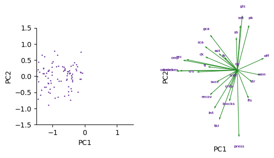

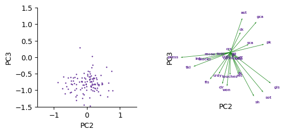

```python
# Define number of PCs
pc_total = 14
X_new = X_norm.dot(w[:, :pc_total])

# Display Caption
display(HTML('<center style="font-size:12px;font-style:default;">'
             '<b> Figure 5.9 Principal Component Biplots - Forwards'
             '</b></center>'))

# Plot 2 biplots for top 3 PCs
plot_pca(X_new, features, w, 3)
```

**Figure 5.10 Top Features for the Top 3 Principal Components - Forwards**

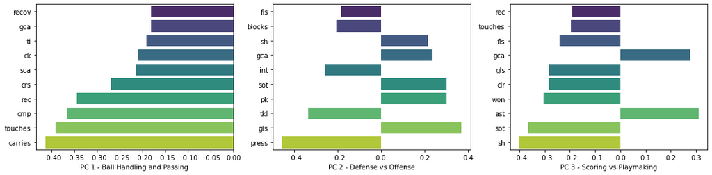

```python
# Display Caption
display(HTML('<center style="font-size:12px;font-style:default;">'
             '<b> Figure 5.10 Top Features for the Top 3 Principal Components'
             ' - Forwards'
             '</b></center>'))

# Plot bar graphs of top features per PC
fig, ax = plt.subplots(1, 3, sharey=False, figsize=(18,4))

trunc_w = w[:, :pc_total]

order = np.argsort(np.abs(trunc_w[:, 0]))[-10:]
sns.barplot(y=features[order], x=trunc_w[order, 0],
            palette='viridis', ax=ax[0])

order = np.argsort(np.abs(trunc_w[:, 1]))[-10:]
sns.barplot(y=features[order], x=trunc_w[order, 1],
            palette='viridis', ax=ax[1])

order = np.argsort(np.abs(trunc_w[:, 2]))[-10:]
sns.barplot(y=features[order], x=trunc_w[order, 2],
            palette='viridis', ax=ax[2])

ax[0].set(xlabel='PC 1 - Ball Handling and Passing', ylabel='')
ax[1].set(xlabel='PC 2 - Defense vs Offense', ylabel='')
ax[2].set(xlabel='PC 3 - Scoring vs Playmaking', ylabel='')

plt.show()
```

### 5.2.1.2 Clustering

The team used Ward's method for clustering. Additionally, a threshold of 3 was utilized to produce four clusters for better balance and distribution.

**Figure 5.11 Dendogram from Wards Method - Forwards**

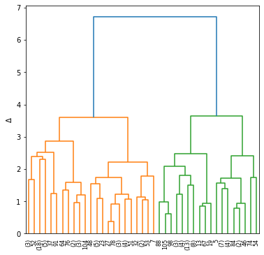

```python
# Scaling
minmax = MinMaxScaler()
X = minmax.fit_transform(df_pca)

stat_columns = df_pca.columns

# PCA
epl_pca = PCA(n_components=14, random_state=1337)
X_new = epl_pca.fit_transform(X)

# Display Caption
display(HTML('<center style="font-size:12px;font-style:default;">'
             '<b> Figure 5.11 Dendogram from Wards Method - Forwards'
             '</b></center>'))

# Wards and Plot
Z = linkage(X, method='ward', optimal_ordering=True)
plot1(Z);
```

**Figure 5.12 Cluster Scatterplot - Forwards**

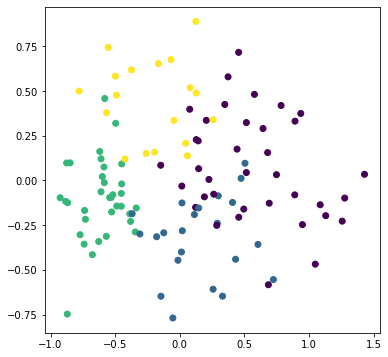

```python
# Display Caption
display(HTML('<center style="font-size:12px;font-style:default;">'
             '<b> Figure 5.12 Cluster Scatterplot - Forwards'
             '</b></center>'))

# Scatter plot on top 2 PCs
y_predict = fcluster(Z, t=3, criterion='distance')
plt.scatter(X_new[:,0], X_new[:,1], c=y_predict);
```

```python
# Combine info df, the processed numerical df and corresponding cluster
df_fw2 = pd.concat([df_info, df_fw], axis=1).dropna()
df_with_cluster = pd.concat([df_fw2.reset_index(), pd.DataFrame(y_predict,
                                            columns=['cluster'])], axis=1)
```

**Figure 5.13 Cluster Feature Boxplots - Forwards**

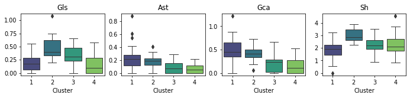

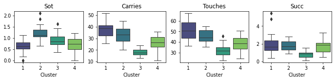

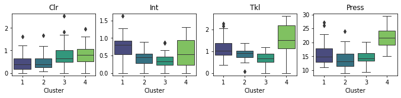

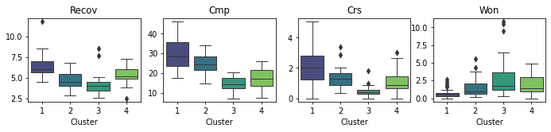

```python
# Display Caption
display(HTML('<center style="font-size:12px;font-style:default;">'
             '<b> Figure 5.13 Cluster Feature Boxplots - Forwards'
             '</b></center>'))

# Feature Boxplots
plot_boxplot_eda(df_with_cluster, 'gls', 'ast', 'gca', 'sh')
plot_boxplot_eda(df_with_cluster, 'sot', 'carries', 'touches', 'succ')
plot_boxplot_eda(df_with_cluster, 'clr', 'int', 'tkl', 'press')
plot_boxplot_eda(df_with_cluster, 'recov','cmp', 'crs', 'won')
```

### Cluster 1 - All-Around Forwards

```python
# Display Caption
display(HTML('<left style="font-size:12px;font-style:default;">'
             '<b>Table 5.1 Sample Players for All Around Forwards</b>'
             '</left>'))

# Display sample players for this cluster
(df_with_cluster[df_with_cluster['cluster'] == 1]
 .sort_values('gls', ascending=False).head(10)[['player', 'squad']])
```

**Table 5.1 Sample Players for All Around Forwards**

|  | player | squad |
| --- | --- | --- |
| 77 | Nicolas Pépé | Arsenal |
| 28 | Phil Foden | Manchester City |
| 39 | Son Heung-min | Tottenham |
| 59 | Riyad Mahrez | Manchester City |
| 47 | Gabriel Jesus | Manchester City |
| 108 | Wilfried Zaha | Crystal Palace |
| 76 | Alex Oxlade-Chamberlain | Liverpool |
| 83 | James Rodríguez | Everton |
| 45 | Daniel James | Manchester Utd |
| 81 | Callum Robinson | West Brom |

### Cluster 2 - Natural Forwards

This cluster includes players that have the affinity to score goals. Scoring is their primary purpose which is evident in their top features. These players can also be called as the ideal forwards. They are players characterized with good ball control and dribbling abilities due to their ability to leave defenders behind. This cluster leads all other clusters in terms of goals scored, shots attempted, and shots on target; and show high scores in dribbling (succ). Some of the famous players under this category are Gareth Bale, Harry Kane, Sergio Aguero, Mohamed Salah, Raheem Sterling, Marcus Rashford and Timo Werner. See table below for other sample players in this cluster.

```python
# Display Caption
display(HTML('<left style="font-size:12px;font-style:default;">'
             '<b>Table 5.2 Sample Players for Natural Forwards</b>'
             '</left>'))

# Display sample players for this cluster
(df_with_cluster[df_with_cluster['cluster'] == 2]
 .sort_values('gls', ascending=False).head(10)[['player', 'squad']])
```

**Table 5.2 Sample Players for Natural Forwards**

|  | player | squad |
| --- | --- | --- |
| 7 | Gareth Bale | Tottenham |
| 41 | Kelechi Iheanacho | Leicester City |
| 51 | Diogo Jota | Liverpool |
| 53 | Harry Kane | Tottenham |
| 2 | Sergio Agüero | Manchester City |
| 87 | Mohamed Salah | Liverpool |
| 32 | Anwar El Ghazi | Aston Villa |
| 93 | Ferrán Torres | Manchester City |
| 3 | Michail Antonio | West Ham |
| 48 | Raúl Jiménez | Wolves |

### Cluster 3 - Aerial Forwards

Players in this cluster are similar to those in the second cluster but are rated lower. Their top features are also related to goal scoring but with a clear lead in aerial duels won (won). Most of these players are also into the physical type of play. Players that are known for their aerial abilities are found in this cluster. These include Tammy Abraham, Dominic Calvert-Lewin, Edinson Cavani, and Olivier Giroud. Refer to the table below for other players included in this cluster.

```python
# Display Caption
display(HTML('<left style="font-size:12px;font-style:default;">'
             '<b>Table 5.3 Sample Players for Aerial Forwards</b>'
             '</left>'))

# Display sample players for this cluster
(df_with_cluster[df_with_cluster['cluster'] == 3]
 .sort_values('gls', ascending=False).head(10)[['player', 'squad']])
```

**Table 5.3 Sample Players for Aerial Forwards**

|  | player | squad |
| --- | --- | --- |
| 21 | Edinson Cavani | Manchester Utd |
| 55 | Alexandre Lacazette | Arsenal |
| 0 | Tammy Abraham | Chelsea |
| 105 | Callum Wilson | Newcastle Utd |
| 8 | Patrick Bamford | Leeds United |
| 18 | Dominic Calvert-Lewin | Everton |
| 42 | Danny Ings | Southampton |
| 13 | Christian Benteke | Crystal Palace |
| 33 | Olivier Giroud | Chelsea |
| 98 | Jamie Vardy | Leicester City |

### Cluster 4 - Defensive-Minded Forwards

This cluster is comprised of players that rate high in defensive features such as clearances, interceptions, tackles, and presses. This shows that although they are forwards, they still take on the role of additional defenders; they track back to defend and do not wait for goal-scoring opportunities. Some notable players in this cluster are Richarlison and Joelinton. See table below for other players comprising this cluster.

```python
# Display Caption
display(HTML('<left style="font-size:12px;font-style:default;">'
             '<b>Table 5.4 Sample Players for Defensive-Minded Forwards</b>'
             '</left>'))

# Display sample players for this cluster
(df_with_cluster[df_with_cluster['cluster'] == 4]
 .sort_values('gls', ascending=False).head(10)[['player', 'squad']])
```

**Table 5.4 Sample Players for Defensive-Minded Forwards**

|  | player | squad |
| --- | --- | --- |
| 26 | Anthony Elanga | Manchester Utd |
| 73 | Eddie Nketiah | Arsenal |
| 46 | Daniel Jebbison | Sheffield Utd |
| 63 | Martinelli | Arsenal |
| 68 | David McGoldrick | Sheffield Utd |
| 80 | Richarlison | Everton |
| 49 | Joelinton | Newcastle Utd |
| 96 | Trézéguet | Aston Villa |
| 92 | Nathan Tella | Southampton |
| 84 | Jay Rodriguez | Burnley |

### 5.2.2 Midfielders

### 5.2.2.1 Principal Component Analysis

Similarly, we will need a **90%** explained variance for **14 principal Components**. Again, we will take the top features for only the top 3 Principal components.

**Figure 5.14 Scree Plot for Explained Variance - Midfielders**

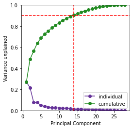

```python
# Prepare dataset for PCA
df_pca = df_mf.copy()

# Display Caption
display(HTML('<center style="font-size:12px;font-style:default;">'
             '<b> Figure 5.14 Scree Plot for Explained Variance - Midfielders'
             '</b></center>'))

# Define X
X = df_pca
features = df_pca.columns

# Scaling
sscaler = MinMaxScaler()
X_norm = sscaler.fit_transform(X.astype(np.float))
X_norm_df = pd.DataFrame(data = X_norm, columns = features)
X_norm_df

X_new, w, variance_explained = pca(X_norm)

# Scree plot
fig, ax = plt.subplots(figsize=(4,4))
ax.plot(range(1, len(variance_explained)+1), variance_explained, 'o-',
        color='rebeccapurple', label='individual')
ax.plot(range(1, len(variance_explained)+1), variance_explained.cumsum(),
        'o-', color='forestgreen', label='cumulative')
ax.legend()
ax.set_ylim(0, 1)
ax.set_xlabel('Principal Component')
ax.axhline(0.90, ls='--', color='r')
ax.axvline(14, ls='--', color='r')
ax.set_ylabel('Variance explained');
```

**PC1** shows top features attributed to offense-related features like goal and shot-creating actions, shot, and shots on target. Although not on the top features, it can be seen in the biplot that those negatively correlated to these offense features are the defense features like recovery, interception clearance, and tackles.

Positive **PC2** dimension top features are related to playmaking with almost no features prominent for its negative axis. Top features include completed passes, ball touches, and recoveries which are all playmaking features.

**PC3** does not give an interpretable correlation of features but it should be noted that the top feature for the positive axis are successful dribbles. Also, the presence of free/penalty/corner kicks is high in the negative axis.

**Figure 5.15 Principal Component Biplots - Midfielders**

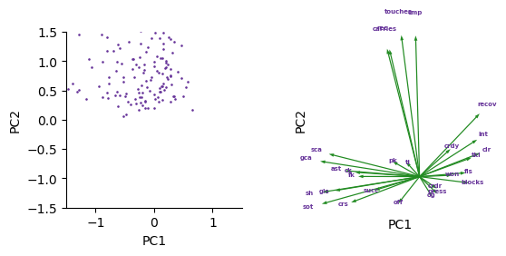

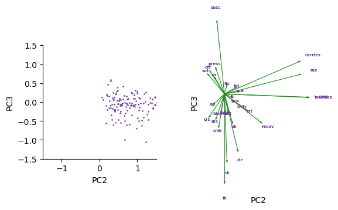

```python
# Define number of PCs
pc_total = 14
X_new = X_norm.dot(w[:, :pc_total])

#Display Caption
display(HTML('<center style="font-size:12px;font-style:default;">'
             '<b> Figure 5.15 Principal Component Biplots - Midfielders'
             '</b></center>'))

# Plot 2 biplots for top 3 PCs
plot_pca(X_new, features, w, 3)
```

**Figure 5.16 Top Features for the Top 3 Principal Components - Midfielders**

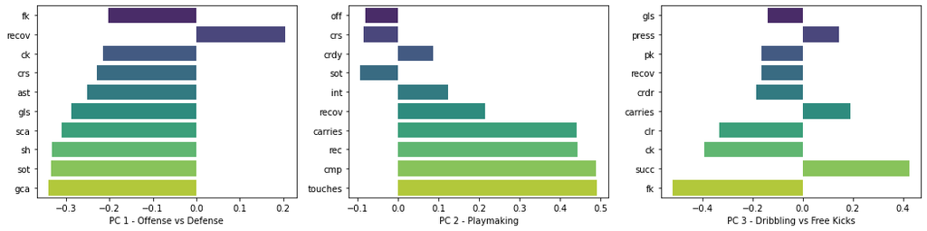

```python
# Display Caption
display(HTML('<center style="font-size:12px;font-style:default;">'
             '<b> Figure 5.16 Top Features for the Top 3 Principal Components'
             ' - Midfielders'
             '</b></center>'))

# Plot bar graphs of top features per PC
fig, ax = plt.subplots(1, 3, sharey=False, figsize=(18,4))

trunc_w = w[:, :pc_total]

order = np.argsort(np.abs(trunc_w[:, 0]))[-10:]
sns.barplot(y=features[order], x=trunc_w[order, 0],
            palette='viridis', ax=ax[0])

order = np.argsort(np.abs(trunc_w[:, 1]))[-10:]
sns.barplot(y=features[order], x=trunc_w[order, 1],
            palette='viridis', ax=ax[1])

order = np.argsort(np.abs(trunc_w[:, 2]))[-10:]
sns.barplot(y=features[order], x=trunc_w[order, 2],
            palette='viridis', ax=ax[2])

ax[0].set(xlabel='PC 1 - Offense vs Defense', ylabel='')
ax[1].set(xlabel='PC 2 - Playmaking', ylabel='')
ax[2].set(xlabel='PC 3 - Dribbling vs Free Kicks', ylabel='')

plt.show()
```

### 5.2.2.2 Clustering

Similarly, clustering was performed using Ward's method. A higher threshold of 3.5 was used to produce four unique clusters.

**Figure 5.17 Dendogram from Wards Method - Midfielders**

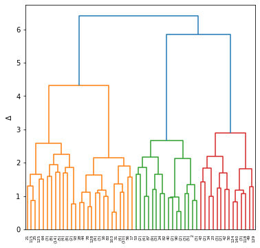

```python
# Scaling
minmax = MinMaxScaler()
X = minmax.fit_transform(df_pca)

stat_columns = df_pca.columns

# PCA
epl_pca = PCA(n_components=14, random_state=1337)
X_new = epl_pca.fit_transform(X)

# Display Caption
display(HTML('<center style="font-size:12px;font-style:default;">'
             '<b> Figure 5.17 Dendogram from Wards Method - Midfielders'
             '</b></center>'))

# Wards and Plot
Z = linkage(X, method='ward', optimal_ordering=True)
plot1(Z);
```

**Figure 5.18 Cluster Scatterplot - Midfielders**

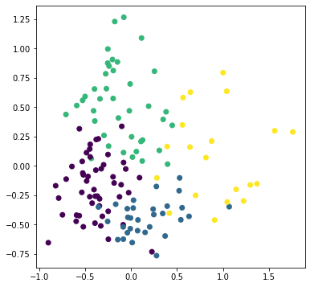

```python
# Display Caption
display(HTML('<center style="font-size:12px;font-style:default;">'
             '<b> Figure 5.18 Cluster Scatterplot - Midfielders'
             '</b></center>'))

# Scatter plot on top 2 PCs
y_predict = fcluster(Z, t=3.5, criterion='distance')
plt.scatter(X_new[:,0], X_new[:,1], c=y_predict);
```

**Figure 5.19 Cluster Feature Boxplots - Midfielders**

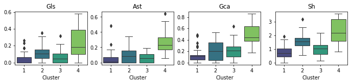

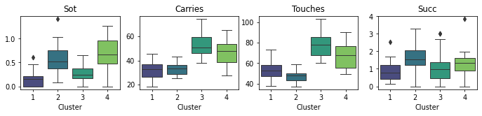

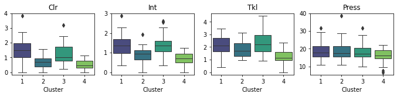

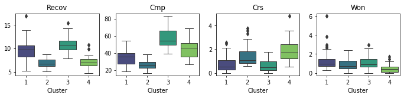

```python
# Display Caption
display(HTML('<center style="font-size:12px;font-style:default;">'
             '<b> Figure 5.19 Cluster Feature Boxplots - Midfielders'
             '</b></center>'))

# Combine info df, the processed numerical df and corresponding cluster
df_mf2 = pd.concat([df_info, df_mf], axis=1).dropna()
df_with_cluster = pd.concat([df_mf2.reset_index(),
                             pd.DataFrame(y_predict, columns=['cluster'])],
                            axis=1)

# Feature Boxplots
plot_boxplot_eda(df_with_cluster, 'gls', 'ast', 'gca', 'sh')
plot_boxplot_eda(df_with_cluster, 'sot', 'carries', 'touches', 'succ')
plot_boxplot_eda(df_with_cluster, 'clr', 'int', 'tkl', 'press')
plot_boxplot_eda(df_with_cluster, 'recov','cmp', 'crs', 'won')
```

### Cluster 1 - Utility Midfielders

Players under this cluster do a little bit of everything in terms of playmaking and defending. These players have an average score in both categories but are notably high in terms of defending features. They are notoriously known to execute a lot of presses and pass interceptions and usually switch between roles in the midfield as the need arises. Some notable players in the cluster are Declan Rice, Scott McTominay, João Moutinho, Tomáš Souček, and Yves Bissouma. Refer to the table below for other sample players belonging to this cluster.

```python
# Display Caption
display(HTML('<left style="font-size:12px;font-style:default;">'
             '<b>Table 5.5 Sample Players for Utility Midfielders</b>'
             '</left>'))

# Display sample players for this cluster
(df_with_cluster[df_with_cluster['cluster'] == 1]
 .sort_values('starts', ascending=False).head(10)[['player', 'squad']])
```

**Table 5.5 Sample Players for Utility Midfielders**

|  | player | squad |
| --- | --- | --- |
| 133 | Ashley Westwood | Burnley |
| 125 | Tomáš Souček | West Ham |
| 12 | Yves Bissouma | Brighton |
| 14 | Josh Brownhill | Burnley |
| 69 | Douglas Luiz | Aston Villa |
| 108 | Declan Rice | West Ham |
| 36 | John Fleck | Sheffield Utd |
| 119 | Jonjo Shelvey | Newcastle Utd |
| 30 | Abdoulaye Doucouré | Everton |
| 85 | João Moutinho | Wolves |

### Cluster 2 - Wide Midfielders

This cluster is comprised of playes that have relatively higher dribbles, assists, goal-creating actions, crosses, and shots. They can be seen as leaning on the offensive type of midfielder and is evident in their low defensive features as well. They usuall play on either side of the flanks which require them to be adept in crosses (passes made from the wide area into the center of the field). They also make forward runs which require them to do a lot of dribbling (succ) and are known to be really fast players. Notable players in this cluster are Ruben Loftus-Cheek, Andros Townsend, Miguel Almiró, Theo Walcott, and Dwight McNeil. Refer to the table below for other players included in this cluster.

```python
# Display Caption
display(HTML('<left style="font-size:12px;font-style:default;">'
             '<b>Table 5.6 Sample Players for Wide Midfielders</b>'
             '</left>'))

# Display sample players for this cluster
(df_with_cluster[df_with_cluster['cluster'] == 2]
 .sort_values('starts', ascending=False).head(10)[['player', 'squad']])
```

**Table 5.6 Sample Players for Wide Midfielders**

|  | player | squad |
| --- | --- | --- |
| 77 | John McGinn | Aston Villa |
| 78 | Dwight McNeil | Burnley |
| 44 | Jack Harrison | Leeds United |
| 5 | Stuart Armstrong | Southampton |
| 33 | Eberechi Eze | Crystal Palace |
| 107 | Bobby Reid | Fulham |
| 3 | Miguel Almirón | Newcastle Utd |
| 28 | Raphael Dias Belloli | Leeds United |
| 128 | Andros Townsend | Crystal Palace |
| 100 | Daniel Podence | Wolves |

### Cluster 3 - Holding Midfielders

Players under this cluster have the highest defensive features like interceptions, tackles, and ball recoveries. They are known to easily take back possession from their opponents and have a high number of completed passes and touches due to the fact that they usually transition from defense to offense. They are also known to execute accurate long and short passes. Some examples of famous players in this cluster are N'Golo Kanté, Jordan Henderson, Rodri, Thomas Partey, Jorginho, and Youri Tielemans. See table below for other players comprising this cluster.

```python
# Display Caption
display(HTML('<left style="font-size:12px;font-style:default;">'
             '<b>Table 5.7 Sample Players for Holding Midfielders</b>'
             '</left>'))

# Display sample players for this cluster
(df_with_cluster[df_with_cluster['cluster'] == 3]
 .sort_values('recov', ascending=False).head(10)[['player', 'squad']])
```

**Table 5.7 Sample Players for Holding Midfielders**

|  | player | squad |
| --- | --- | --- |
| 19 | Hamza Choudhury | Leicester City |
| 113 | Oriol Romeu | Southampton |
| 111 | Rodri | Manchester City |
| 132 | James Ward-Prowse | Southampton |
| 47 | Jordan Henderson | Liverpool |
| 87 | Wilfred Ndidi | Leicester City |
| 80 | Nampalys Mendy | Leicester City |
| 54 | N'Golo Kanté | Chelsea |
| 82 | James Milner | Liverpool |
| 37 | Fred | Manchester Utd |

### Cluster 4 - Attack-Minded Midfielders

For the last midfielder cluster, the players usually have the highest offense-related features among the midfielder types. They top the group in terms of goals scored and number of shots made. They also score fairly high on playmaking features like completed passes, carries, touches, and crosses; and consequently have low ratings in defending stats. These players are usually called forward-midfielder hybrids as they contribute a lot to the offense of the team. Some famous players under this category are Bruno Fernandes, Mason Mount, Kevin De Bruyne, James Maddison and Bernardo Silva. See table below for other sample players in this cluster.

```python
# Display Caption
display(HTML('<left style="font-size:12px;font-style:default;">'
             '<b>Table 5.8 Sample Players for Attack-Minded Midfielders</b>'
             '</left>'))

# Display sample players for this cluster
(df_with_cluster[df_with_cluster['cluster'] == 4]
 .sort_values('starts', ascending=False).head(10)[['player', 'squad']])
```

**Table 5.8 Sample Players for Attack-Minded Midfielders**

|  | player | squad |
| --- | --- | --- |
| 34 | Bruno Fernandes | Manchester Utd |
| 84 | Mason Mount | Chelsea |
| 96 | Matheus Pereira | West Brom |
| 42 | Pascal Groß | Brighton |
| 121 | Bernardo Silva | Manchester City |
| 120 | Gylfi Sigurðsson | Everton |
| 72 | James Maddison | Leicester City |
| 23 | Kevin De Bruyne | Manchester City |
| 43 | İlkay Gündoğan | Manchester City |
| 124 | Emile Smith-Rowe | Arsenal |